# Word Cloud

B05401102

2018年10月7日

#### **主題**：文字雲–比較川普、歐巴馬相關的新聞標題關鍵字

#### **文字資料來源**：[聯合新聞網](https://udn.com/news/index)

#### **說明**：

- 從聯合新聞網上分別搜尋川普與歐巴馬，爬蟲擷取新聞標題，並進行詞語分析，製造出文字雲，並比較兩者的異同
- 以下步驟先以**川普**的資料進行說明。

### **1. Data Input-Web Crawler**

> 利用**rvest package**爬蟲，目標為搜尋**川普**前20頁的搜尋結果，並將標題擷取，輸出為`trump_title.csv`。
- 觀察搜尋結果換頁時，網址末數會變，因此可以利用`for loop`搜索多頁的資料。
- 由於爬蟲時間需要蠻久的，所以只擷取了20頁約400筆標題資料。
- 利用paste0函數避免paste時字串中間產生間隔。

```r
library(rvest)
trump_title <- c()
for(i in 1:20){
  t <- read_html(paste0("https://udn.com/search/tagging/2/%E5%B7%9D%E6%99%AE/",i))%>%
       html_nodes("#search_content h2") %>% html_text()
  trump_title <- c(trump_title,t)
  i <- i+1
}
write.csv(trump_title,"trump_title.csv")
```

### **2. Data processing**

> 先引入所需要的packages, 並輸入`trump_title.csv`。

```r
library(NLP)
library(tm)
library(jiebaRD)
library(jiebaR)
library(RColorBrewer)
library(wordcloud)
library(wordcloud2)


trump<-read.csv("trump_title", stringsAsFactors = F)
obama<-read.csv("obama_title", stringsAsFactors = F)
```

> 刪除大量出現的「川普」二字和不必要的符號、數字後，利用**jiebaR package** 的內建辭庫處理標題文字，將句子分割成字詞。

```r
docs <- Corpus(VectorSource(trump))
toSpace <- content_transformer(function(x, pattern) {
  return (gsub(pattern, " ", x))
}
)
docs <- tm_map(docs, toSpace, "川普")
docs <- tm_map(docs, toSpace, "‧")
docs <- tm_map(docs, removePunctuation)
docs <- tm_map(docs, removeNumbers)
docs <- tm_map(docs, stripWhitespace)
mixseg = worker()
new_user_word(mixseg,"卡瓦諾")
```

```
## [1] TRUE
```

```r
jieba_tokenizer=function(d){
  unlist(segment(d[[1]],mixseg))
}
seg = lapply(docs, jieba_tokenizer)
```

> 建立字詞(Var1)與字詞頻率(Freq)的data frame，依照頻率由高而低排列，並刪除字元長度為1的字詞。

```r
freqFrame_a <- as.data.frame(table(unlist(seg)))
freqFrame_a_ordered <- freqFrame_a[order(freqFrame_a$Freq, decreasing = T),]
freqFrame_a_clean <- freqFrame_a_ordered[-which(nchar(as.character(freqFrame_a_ordered$Var1))==1),]
```

### **3. Plotting**

> 繪製頻率最高的30個字詞與其出現次數的長條圖。

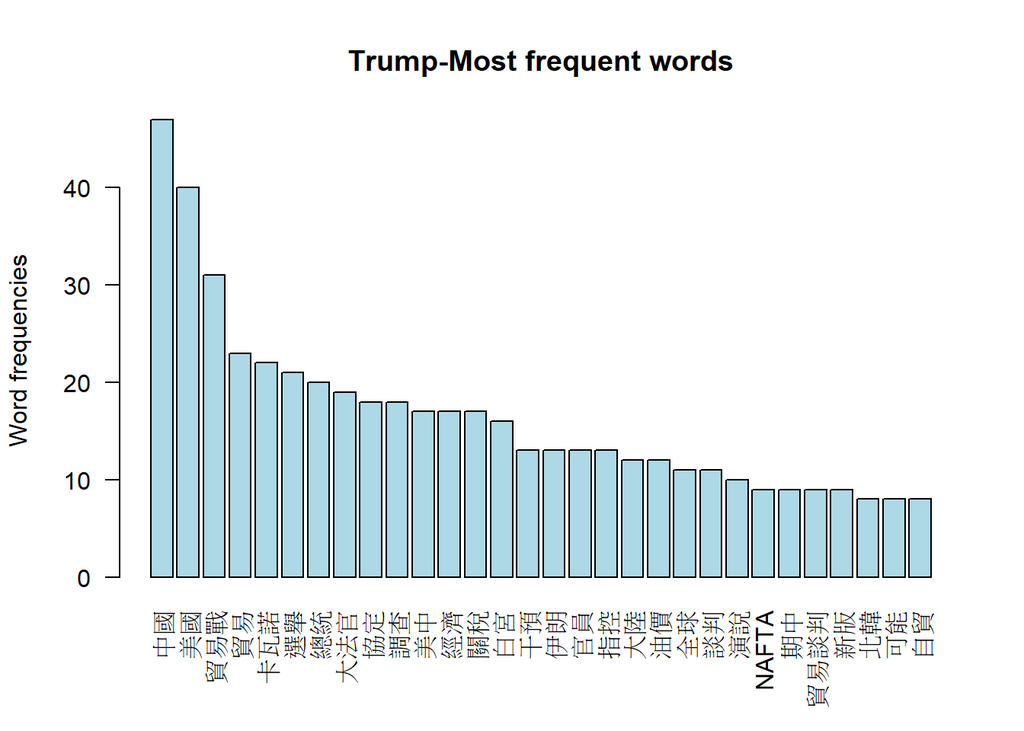

```r
barplot(freqFrame_a_clean$Freq[1:30],
        names.arg = freqFrame_a_clean$Var1[1:30],
        col ="lightblue",
        main ="Trump-Most frequent words",
        las = 2,
        ylab = "Word frequencies")
```

> 利用**wordcloud2 package**繪製文字雲。
- 一開始讀取的結果裡有「卡瓦」一詞，觀察文字資料庫後發現其應為「卡瓦諾」，因此用`new_user_word(mixseg,"卡瓦諾")`新增詞彙。
- 由於`wordcloud2`這個function存取的文字雲為動態(dynamic)的文字雲，要同時在一份markdown文件中顯示兩個文字雲的話，就必須把動態文字雲利用**htmlwidgets package**和**webshot package**存成靜態png檔再匯入，才能顯示。

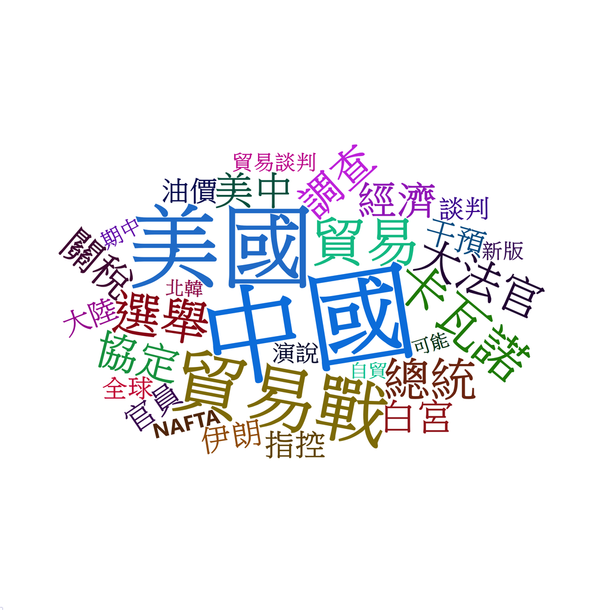

```r
trump_cloud <- wordcloud2(freqFrame_a_clean[1:30,], size = 2.0)
library(htmlwidgets)
library(webshot)
saveWidget(trump_cloud, "trump.html", selfcontained = F)
webshot("trump.html", "trump.png", delay = 5, vwidth = 2000, vheight = 2000)
```

川普文字雲

### **4. Repeat**

> 對**歐巴馬**如法炮製，結果如下。
- 一開始讀取的結果裡有「利王子」一詞，觀察文字資料庫後發現其應為「哈利王子」，因此用`new_user_word(mixseg,"哈利王子")`新增詞彙。

```r
docs <- Corpus(VectorSource(obama))
toSpace <- content_transformer(function(x, pattern) {
  return (gsub(pattern, " ", x))
}
)
docs <- tm_map(docs, toSpace, "歐巴馬")
docs <- tm_map(docs, toSpace, "‧")
docs <- tm_map(docs, removePunctuation)
docs <- tm_map(docs, removeNumbers)
docs <- tm_map(docs, stripWhitespace)
mixseg = worker()
new_user_word(mixseg,"哈利王子")
```

```
## [1] TRUE
```

```r
jieba_tokenizer=function(d){
  unlist(segment(d[[1]],mixseg))
}
seg = lapply(docs, jieba_tokenizer)
freqFrame <- as.data.frame(table(unlist(seg)))
freqFrame_ordered <- freqFrame[order(freqFrame$Freq, decreasing = T),]
freqFrame_f <- freqFrame_ordered[-which(nchar(as.character(freqFrame_ordered$Var1))==1),]
```

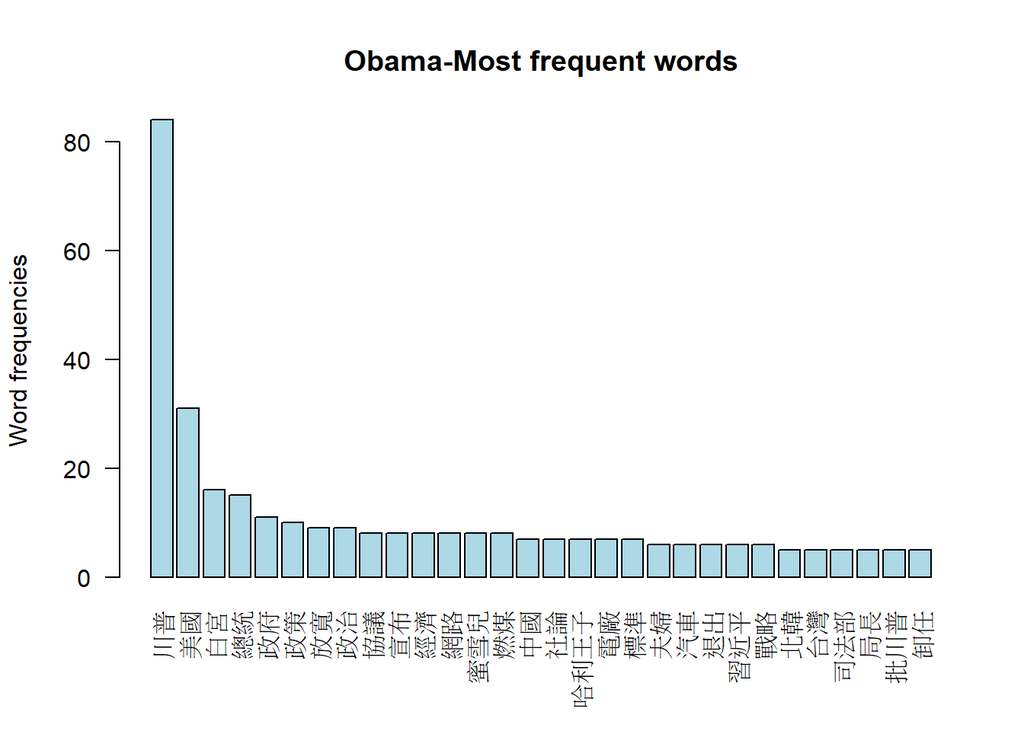

```r
barplot(freqFrame_f$Freq[1:30],
        names.arg = freqFrame_f$Var1[1:30],
        col ="lightblue",
        main ="Obama-Most frequent words",
        las = 2,
        ylab = "Word frequencies")
```

- 由於「川普」佔的比例過大，也沒有比較的意義，所以決定刪除它，繪製歐巴馬文字雲。

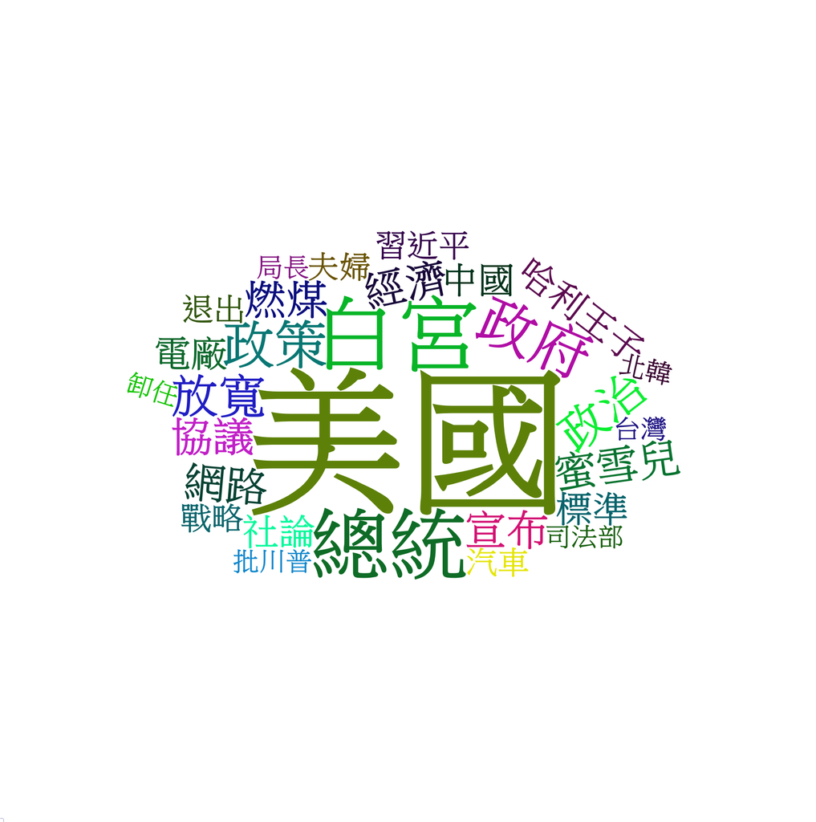

```r
obama_cloud <- wordcloud2(freqFrame_f[2:30,], size = 2.2)

saveWidget(obama_cloud, "obama.html", selfcontained = F)
webshot("obama.html", "obama.png", delay = 5, vwidth = 2000, vheight = 2000)
```

歐巴馬文字雲

### **5. Intepretation**

> 比對這兩張文字雲。可以發現一些特點。
1. 美國、中國顯然是這兩位總統最近都很關心的議題。
2. 川普的新聞主題集中在經濟上，包含**貿易**、**關稅**、**NAFTA**等，特別是**貿易**。
3. 歐巴馬雖然已經卸任，但可以推測他在許多內政、外交議題上仍然有發表自己的看法。
4. 川普的新聞關鍵字還包含最近具爭議性的**卡瓦諾**大法官醜聞。有比較負面的關鍵字(ex.**指控**)。相反地，歐巴馬已經卸任，爭議不多，關鍵字包含**蜜雪兒**、**哈利王子**等。
5. 歐巴馬的關鍵字中還有**台灣**，值得探討成因。